```
# Notebook for Classification using Multi-layer perceptron (MLP)
```

# Choice of embeddings:

Bert (Pre-trained)  
word2vec (custom trained)  
(set them in global variables)

```python
from pandas._libs.hashtable import value_count
import pandas as pd
import numpy as np
import re
import os
import time
import unicodedata
from gensim.models import Word2Vec
from tqdm import tqdm
import seaborn as sns
from sklearn.model_selection import train_test_split
from sklearn import preprocessing
import matplotlib.pyplot as plt
%matplotlib inline
tqdm.pandas()
lb = preprocessing.LabelBinarizer()

# global variables/flags
BALANCED_SAMPLING = False
BALANCED_SAMPLING_ATMOST = 25
WORD2VEC_EMBEDDING_DIMENSION = 100 # word2vec
CREATE_ONEHOT_COUNTRY = False
HYPERPARAMETER_SEARCH = False
# choose one the embeddings type from below
APPLY_WORD2VEC_EMBEDDINGS = False
APPLY_BERT_EMBEDDINGS = True

# loading csv file into dataframe using utf-8 encoding
orig_df = pd.read_csv('train_lenses_ds_task.csv', encoding='utf-8')

# NOTE: if read_csv gives encoding error, open the csv file in sublime or other
# text editor and save it with utf-8 encoding and try again

df = orig_df.drop(columns=['mdm_brand_text', 'mdm_model_text'], axis=1)
df = orig_df.drop_duplicates(keep='first') # drop dupliactes
df = df.dropna() # drop NaN
df = df.apply(lambda x: x.astype(str).str.lower()) # all string to upper case

# for labels
lb.fit(df['item_id'])

# balanced sampling take atmost-25 entries for each count
if BALANCED_SAMPLING:
  df_high = df[df.groupby('item_id').transform('count').ge(BALANCED_SAMPLING_ATMOST)['main_text']]
  df_low = df[df.groupby('item_id').transform('count').lt(BALANCED_SAMPLING_ATMOST)['main_text']]
  df_high = df_high.groupby('item_id', group_keys=False).apply(lambda x: x.sample(BALANCED_SAMPLING_ATMOST))
  df = pd.concat([df_low, df_high], axis=0)

print('total unique entries:', len(df)) # 2868

# unique values in each columns
for column in df.columns:
    #prinfting unique values
    print(column ,':', len(df[column].unique()))

# finding the top 20 categories
print('class distribution for item_id top 5', df.item_id.value_counts().sort_values(ascending=False).head(5))
print('class distribution for item_id bottom 5', df.item_id.value_counts().sort_values(ascending=True).head(5))
# print('distribution for country_name', df.country_name.value_counts().sort_values(ascending=False).head(20))

# creating one-hot encoding for categorical varaible country_name
if CREATE_ONEHOT_COUNTRY:
  df_categorical = pd.get_dummies(df.country_name, prefix='country')
  df = pd.concat([df, df_categorical], axis=1)
  df = df.drop('country_name', axis=1)

# df.head(30)
```

```
total unique entries: 2868
item_id : 260
main_text : 2805
country_name : 2
retailer_pg : 49
mdm_brand_text : 23
mdm_model_text : 253
class distribution for item_id top 5 82981040     268
138176095    189
87099837     114
79429232      51
88210952      50
Name: item_id, dtype: int64
class distribution for item_id bottom 5 83636387     1
81343196     1
106799763    2
108361704    2
112072950    2
Name: item_id, dtype: int64
```

Total unique entries in the data: 2868

There are only 2 categories in country_name: i.e.  
Spain count: 2094  
Germany count: 774

Total different item_ids(y-label): 260  
out of which 65 of them have less than 5 entries.

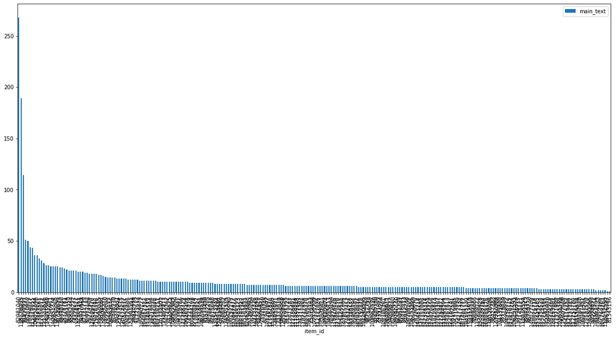

```python
# code for visualization of class distribution
df2 = df.groupby('item_id').count().reset_index()[['item_id', 'main_text']]
df2 = df2.sort_values('main_text', ascending=False)
df2 = df2[df2['main_text']<500]

df2.plot(kind='bar', x='item_id', figsize=(20,10))
plt.xticks(rotation='vertical')
plt.show()
```

```python
# making train test split
# train split = 80%
# test split = 20%

train, test = train_test_split(df, test_size=0.2, random_state=12)

print(len(train)) #2294
print(len(test)) #574
```

```
2294
574
```

```python
# preprocessing/cleaning of data

word2vec_processed_array = []
vocabulary = []

def strip_accents(text):
  """
    Strip accents from input String.

    :param text: The input string.
    :type text: String.

    :returns: The processed String.
    :rtype: String.
    """
  text = unicodedata.normalize('NFD', text)
  text = text.encode('ascii', 'ignore')
  text = text.decode("utf-8")
  return str(text)


def preprocess(text, is_train):
  """
    Instead of tokenizing directly removing all punctuations, here
    we handle numerical data first, and remove all other special characters.

    Replace all numberical data seperator from (',' or '-' or ',') to '_'
    Example:
    02.25 = 02_25
    02,25 = 02_25
    02-25 = 02_25
    2.2 = 2_2

    Note: must contain number both side of the special_character
    This step is done to maintain the relationship that numerical data may have

    Then we replace all special characters and punctuations except '_' with ' '

    Note: we also build the vocabulary of sentences found only in training data
    (is_train) = True, so that we can train custom word2vec model for embeddings

    :param text: The input string.
    :type text: String.

    :param is_train: build vocabulary is is_train = True
    :type text: Boolean.

    :returns: The processed String.
    :rtype: String.
    """

  processed_text = re.sub('([0-9]+)[,|.|-]([0-9]+)', '\\1_\\2', text)
  processed_text = re.sub('\W+',' ', processed_text)
  processed_text = processed_text.strip()

  processed_text = strip_accents(processed_text)
  # sent = ' '.join(word for word in processed_text.split() if len(word)>1)

  if is_train: # as embedding model will be trained only with training data
    processed_words = processed_text.split()
    word2vec_processed_array.append(processed_words)
    vocabulary.extend(processed_words)

  return processed_text
```

```python
def preprocess_main(data, is_train=False):
  """
    Main function to preprocess both train and test data
    We combine 'main_text' and 'retailer_pg' and 'country_name'
    and store it to 'feature_text' column in the dataframe.
    And pass them to preprocess method to clean the text
    'main_text','retailer_pg','country_name' is then dropped from the dataframe

    :param data: Dataframe of train or test split
    :type data: Dataframe.
    :param is_train: build vocabulary is is_train = True
    :type text: Boolean.

    :returns: Dataframe
    :rtype: String.
    """

  for index, row in data.iterrows():
    text = row['main_text'] + ' ' + row['retailer_pg'] + ' ' + row['country_name']
    # get clean processed text from preprocess method
    clean_text = preprocess(text, is_train)
    # assign clean text to new column feature_text
    data.loc[index, 'feature_text'] = clean_text

  data = data.drop(columns=['main_text', 'retailer_pg', 'country_name'], axis=1)
  return data
```

```python
# pass train and test splits(dataframe) to preprocess method
train = preprocess_main(train, is_train=True)
test = preprocess_main(test)

# seperate train label Y train
y_train = train.pop('item_id')
y_train = lb.transform(y_train) # transform item_id in range [0,260]
print(y_train.shape)

# seperate test label Y test:
y_test = test.pop('item_id')
y_test = lb.transform(y_test) # transform item_id in range [0,260]
print(y_test.shape)
```

```
(2294, 260)
(574, 260)
```

# Training Custom Word2Vec

```python
# Train custom word2Vec model from Gensim
# Sentences are processed sentences('main_text' + 'retailer_pg')
# sentences only involve training data.

if APPLY_WORD2VEC_EMBEDDINGS:
  start_time = time.time()

  word2vec_model = Word2Vec(sentences=word2vec_processed_array,
                  sg=1, # 1 for skip_gram, 0 for CBOW
                  min_count=1,
                  size=WORD2VEC_EMBEDDING_DIMENSION,
                  workers=4)

  print(f'Time taken : {(time.time() - start_time) / 60:.2f} mins')

  keys = set(word2vec_model.wv.vocab.keys())
  print('Total vocab of trained word2vec model:', len(keys))
  print('Dimension of trained word2vec vectors:',word2vec_model.wv.vector_size)
  # print(model.wv.get_vector('CRISTALES'))

  # Save the word2vec model
  word2vec_model.wv.save_word2vec_format('custom_word2vec_model_100d.txt')
  word_vectors = word2vec_model
```

```python
def apply_word2vec(data):
  """
  For each data row, take embedding vector for each token in the sentence
  from the trained word2vec model
  and take mean of those vectors to for one vector for a sentence.
  """

  D = WORD2VEC_EMBEDDING_DIMENSION
  X = np.zeros((len(data), D))
  n = 0
  emptycount = 0
  for rows in data:
    tokens = rows.split()
    vecs = []
    m = 0
    for word in tokens:
      try:
        # throws KeyError if word not found
        vec = word_vectors.wv.get_vector(word)
        vecs.append(vec)
        m += 1
      except KeyError:
        pass
    if len(vecs) > 0:
      vecs = np.array(vecs)
      X[n] = vecs.mean(axis=0)
    else:
      emptycount += 1
    n += 1
  print("Numer of samples with no words found: %s / %s" % (emptycount, len(data)))
  return X
```

## BERT Embeddings:

```python
if APPLY_BERT_EMBEDDINGS:
  !pip install -U sentence-transformers
  from sentence_transformers import SentenceTransformer

  bert_model = SentenceTransformer('sentence-transformers/bert-base-nli-mean-tokens')

def get_bert_embeddings(data):
  '''
  Apply bert embeddings to sentences provided in dataframe
  :param data: Series of sentences
  :type data: Dataframe Series

  :returns: list of embeddings of sentences
  :shape: (num_of_sentences, bert_embd_dimension)
  :rtype: List of List.
  '''
  D = 768
  data = data.to_list()
  embeddings = bert_model.encode(data)
  return embeddings
```

[output not shown]

For Bert embeddings:  
We directly ger embeddings of the complete sentence

```python
# Generating embeddings of train/test using Bert

if APPLY_BERT_EMBEDDINGS:
  # Train:
  # Get the features(embedding vectors) for train data
  x_train = get_bert_embeddings(train['feature_text'])
  print(x_train.shape)

  # Test:
  # Get the features(embedding vectors) for test data
  x_test = get_bert_embeddings(test['feature_text'])
  print(x_test.shape)
```

```
(2294, 768)
(574, 768)
```

For word2vec embeddings:  
We can get the embeddings of complete sentence in feature_text by taking mean of all embedding vectors of its words.

```python
# Generating embeddings of train/test using word2vec

if APPLY_WORD2VEC_EMBEDDINGS:
  # Train:
  # Get the features(embedding vectors) for train data
  x_train = apply_word2vec(train['feature_text'])
  print(x_train.shape)

  if CREATE_ONEHOT_COUNTRY:
    # Add features from one-hot encoding of country
    country_train = train[['country_GERMANY', 'country_SPAIN']].to_numpy()
    print(country_train.shape)

    x_train = np.concatenate((x_train, country_train), axis=1)
    print(x_train.shape)

  # Test:
  # Get the features(embedding vectors) for test data
  x_test = apply_word2vec(test['feature_text'])
  print(x_test.shape)

  if CREATE_ONEHOT_COUNTRY:
    # Add features from one-hot encoding of country
    country_test = test[['country_GERMANY', 'country_SPAIN']].to_numpy()
    print(country_test.shape)

    x_test = np.concatenate((x_test, country_test), axis=1)
    print(x_test.shape)
```

## Deep Learning Classifier

We train a neural network MLP model to classify 'item_id'

Parameters of the network:

1. Input Dimension: 768
2. Hidden Layer 1: 1024
3. Hidden Layer 2: 512
4. Output Layer 260

```python
import numpy as np

import torch
import torch.nn as nn
import torch.optim as optim
from torch.autograd import Variable
from torch.utils.data import Dataset, DataLoader

# seed for reproducibility
import random
seed = 0
torch.manual_seed(seed)
torch.cuda.manual_seed(seed)
torch.cuda.manual_seed_all(seed)  # if you are using multi-GPU.
np.random.seed(seed)  # Numpy module.
random.seed(seed)  # Python random module.
torch.manual_seed(seed)
torch.backends.cudnn.benchmark = False
torch.backends.cudnn.deterministic = True
device = torch.device("cuda" if torch.cuda.is_available() else "cpu")
print(f"Using: {device} device")

class AnkitDataset(Dataset):
    def __init__(self, feature_list, target_list):
        self.feature_list = feature_list
        self.target_list = target_list

    def __getitem__(self, index: int):
        feature = self.feature_list[index]
        target = self.target_list[index]

        return feature, target

    def __len__(self):
        return len(self.feature_list)


class AnkitNet(nn.Module):
  def __init__(self):
    super().__init__()

    if APPLY_BERT_EMBEDDINGS:
      self.fc1 = nn.Linear(768, 1024, bias=False)
      self.relu = nn.ReLU()
      self.fc2 = nn.Linear(1024, 512, bias=False)
      self.fc3 = nn.Linear(512, 260, bias=False)
    if APPLY_WORD2VEC_EMBEDDINGS:
      self.fc1 = nn.Linear(100, 256, bias=False)
      self.relu = nn.ReLU()
      self.fc2 = nn.Linear(256, 512, bias=False)
      self.fc3 = nn.Linear(512, 260, bias=False)

  def forward(self, x):
    out = self.fc1(x)
    out = self.relu(out)
    out = self.fc2(out)
    out = self.relu(out)
    out = self.fc3(out)

    return out


def Accuracy(gt, pred):
  accuracy_results = {'accuracy': 0}
  count = 0
  for i in range(len(gt)):
    if sum(np.logical_and(np.array(gt[i]), np.array(pred[i]))):
      count+= 1

  accuracy_results['accuracy'] = count/len(gt)
  return accuracy_results


def train(model, train_loader, criterion, optimizer, epochs):
  model.train()

  for epoch in range(epochs):
    losses = []
    for idx, (data, label) in enumerate(train_loader):
      data = data.float().to(device)
      label = label.float().to(device)

      model.to(device)
      inputv = data
      labelsv = label

      output = model(inputv)
      loss = criterion(output, labelsv)

      optimizer.zero_grad()
      loss.backward()
      optimizer.step()
    losses.append(loss.item())
    # print(f"Epoch: {epoch + 1}, Loss: {(losses)}")
  return model

def test(model, test_loader):
  model.eval()
  gt = []
  pred = []

  for idx, (data, label) in enumerate(test_loader):
    data = data.float().to(device)
    label = label.float().to(device)

    inputv = Variable(data)
    labelsv = Variable(label)

    output = model(inputv)
    output = torch.nn.functional.softmax(output, dim=1)
    output = output.float() > 0.5

    gt.extend(labelsv.detach().cpu())
    pred.extend(output.detach().cpu())

  return Accuracy(gt, pred)


def seed_worker(worker_id):
    worker_seed = torch.initial_seed() % 2**32
    np.random.seed(worker_seed)
    random.seed(worker_seed)


def ankit_trainer(train_input:list=None, train_target:list=None,
                  test_input:list=None, test_target:list=None,
                  epoch:int=250, bs:int=16, lr:float=1e-3):

  train_dataset = AnkitDataset(np.array(train_input), np.array(train_target))
  test_dataset = AnkitDataset(np.array(test_input), np.array(test_target))

  train_dl = DataLoader(train_dataset, batch_size = bs, shuffle = True, num_workers=0)
  test_dl = DataLoader(test_dataset, batch_size = 16, shuffle = False, num_workers=0)

  model = AnkitNet()

  optimizer = optim.Adam(model.parameters(), lr=lr)
  criterion = nn.CrossEntropyLoss()

  model = train(model, train_dl, criterion, optimizer, epoch)
  accuracy_results = test(model, test_dl)
  return accuracy_results

if __name__ == "__main__":
  # Hyperparameter search
  epochs = [50, 100, 150, 200, 300, 400]
  batch_size = [8, 12, 32, 64, 128]
  # epochs = [2,2,2]
  for epoch in epochs:
    for bs in batch_size:
      if epoch in (300,400) and bs in (8,12):
        continue
      print('\nepoch value =:', epoch)
      print('Batch Size =:', bs)
      results = ankit_trainer(x_train, y_train, x_test, y_test, epoch, bs)
      print('Accuracy:', results)

  ## debug
  # results = ankit_trainer(x_train, y_train, x_test, y_test, 5, 8)
  # print('Accuracy:', results)
```

```
Using: cuda device

epoch value =: 50
Batch Size =: 8
Accuracy: {'accuracy': 0.7282229965156795}

epoch value =: 50
Batch Size =: 12
Accuracy: {'accuracy': 0.7717770034843205}

epoch value =: 50
Batch Size =: 32
Accuracy: {'accuracy': 0.7961672473867596}

epoch value =: 50
Batch Size =: 64
Accuracy: {'accuracy': 0.813588850174216}

epoch value =: 50
Batch Size =: 128
Accuracy: {'accuracy': 0.8048780487804879}

epoch value =: 100
Batch Size =: 8
Accuracy: {'accuracy': 0.7874564459930313}

epoch value =: 100
Batch Size =: 12
Accuracy: {'accuracy': 0.7857142857142857}

epoch value =: 100
Batch Size =: 32
Accuracy: {'accuracy': 0.7229965156794426}

epoch value =: 100
Batch Size =: 64
Accuracy: {'accuracy': 0.8362369337979094}

epoch value =: 100
Batch Size =: 128
```

[output cut: 50 more lines]

```
epoch value =: 300
Batch Size =: 128
Accuracy: {'accuracy': 0.8501742160278746}

epoch value =: 400
Batch Size =: 32
Accuracy: {'accuracy': 0.8170731707317073}

epoch value =: 400
Batch Size =: 64
Accuracy: {'accuracy': 0.8432055749128919}

epoch value =: 400
Batch Size =: 128
Accuracy: {'accuracy': 0.8484320557491289}
```